# Enron Dataset

安然曾是 2000 年美国最大的公司之一。2002 年，由于其存在大量的企业欺诈行为，这个昔日的大集团土崩瓦解。 在随后联邦进行的调查过程中，大量有代表性的保密信息进入了公众的视线，包括成千上万涉及高管的邮件和详细的财务数据。

本项目目的是根据安然数据集（邮件及财务数据）以及涉案人员标签（POI）使用机器学习算法训练模型，该模型可以从根据人员信息较准确的预测出是否为涉案人员。

## 数据概览

```python
# 导入数据

import sys
import pickle
import numpy as np
import pandas as pd
from pprint import pprint

### Load the dictionary containing the dataset
with open("final_project_dataset.pkl", "r") as data_file:
    data_dict = pickle.load(data_file)

### Construct DataFrame from ict
raw_df = pd.DataFrame.from_dict(data_dict, orient='index', dtype=np.float)

### reorder the features
payments_features = ['salary', 'bonus', 'long_term_incentive', 'deferred_income', 'deferral_payments',
                     'loan_advances', 'other', 'expenses', 'director_fees', 'total_payments']
stock_features = ['exercised_stock_options', 'restricted_stock', 'restricted_stock_deferred', 'total_stock_value']
email_features = list(set(raw_df.columns) - set(payments_features) - set(stock_features) - {'poi'})
email_features.sort()

raw_df = raw_df[['poi'] + payments_features + stock_features + email_features]

### change poi datatype
raw_df['poi'] = raw_df['poi'].astype(np.bool)

print(raw_df.info())
raw_df.head()
```

```
<class 'pandas.core.frame.DataFrame'>
Index: 146 entries, ALLEN PHILLIP K to YEAP SOON
Data columns (total 21 columns):
poi                          146 non-null bool
salary                       95 non-null float64
bonus                        82 non-null float64
long_term_incentive          66 non-null float64
deferred_income              49 non-null float64
deferral_payments            39 non-null float64
loan_advances                4 non-null float64
other                        93 non-null float64
expenses                     95 non-null float64
director_fees                17 non-null float64
total_payments               125 non-null float64
exercised_stock_options      102 non-null float64
restricted_stock             110 non-null float64
restricted_stock_deferred    18 non-null float64
total_stock_value            126 non-null float64
email_address                146 non-null object
from_messages                86 non-null float64
from_poi_to_this_person      86 non-null float64
from_this_person_to_poi      86 non-null float64
shared_receipt_with_poi      86 non-null float64
to_messages                  86 non-null float64
dtypes: bool(1), float64(19), object(1)
memory usage: 24.1+ KB
None
```

|  | poi | salary | bonus | long_term_incentive | deferred_income | deferral_payments | loan_advances | other | expenses | director_fees | ... | exercised_stock_options | restricted_stock | restricted_stock_deferred | total_stock_value | email_address | from_messages | from_poi_to_this_person | from_this_person_to_poi | shared_receipt_with_poi | to_messages |
| --- | --- | --- | --- | --- | --- | --- | --- | --- | --- | --- | --- | --- | --- | --- | --- | --- | --- | --- | --- | --- | --- |
| ALLEN PHILLIP K | False | 201955.0 | 4175000.0 | 304805.0 | -3081055.0 | 2869717.0 | NaN | 152.0 | 13868.0 | NaN | ... | 1729541.0 | 126027.0 | -126027.0 | 1729541.0 | phillip.allen@enron.com | 2195.0 | 47.0 | 65.0 | 1407.0 | 2902.0 |
| BADUM JAMES P | False | NaN | NaN | NaN | NaN | 178980.0 | NaN | NaN | 3486.0 | NaN | ... | 257817.0 | NaN | NaN | 257817.0 | NaN | NaN | NaN | NaN | NaN | NaN |
| BANNANTINE JAMES M | False | 477.0 | NaN | NaN | -5104.0 | NaN | NaN | 864523.0 | 56301.0 | NaN | ... | 4046157.0 | 1757552.0 | -560222.0 | 5243487.0 | james.bannantine@enron.com | 29.0 | 39.0 | 0.0 | 465.0 | 566.0 |
| BAXTER JOHN C | False | 267102.0 | 1200000.0 | 1586055.0 | -1386055.0 | 1295738.0 | NaN | 2660303.0 | 11200.0 | NaN | ... | 6680544.0 | 3942714.0 | NaN | 10623258.0 | NaN | NaN | NaN | NaN | NaN | NaN |
| BAY FRANKLIN R | False | 239671.0 | 400000.0 | NaN | -201641.0 | 260455.0 | NaN | 69.0 | 129142.0 | NaN | ... | NaN | 145796.0 | -82782.0 | 63014.0 | frank.bay@enron.com | NaN | NaN | NaN | NaN | NaN |

5 rows × 21 columns

财务信息中loan_advances只有4条记录有具体值，但这些财务数据的缺失值均可以认为是0。

这份数据，一是数据量太少，二是信息也并不完整，所以使用机器学习算法训练出较好模型比较困难。

```python
# poi/non-poi
print (raw_df['poi'].value_counts())
```

```
False    128
True      18
Name: poi, dtype: int64
```

这146个人中， 标记为POI的只有 18个，占较少的一部分（ 12.3%)。数据集很不平衡（imbalance），如果对所有特征，预测结果都是非POI，那么也有 87.7% 的准确率。所以使用准确率（accuracy）指标并不能很好的评估模型性能，可以使用precision和recall指标来评估模型。

## 数据预处理

### 异常值（outlier）

|  | poi | salary | bonus | long_term_incentive | deferred_income | deferral_payments | loan_advances | other | expenses | director_fees | ... | exercised_stock_options | restricted_stock | restricted_stock_deferred | total_stock_value | email_address | from_messages | from_poi_to_this_person | from_this_person_to_poi | shared_receipt_with_poi | to_messages |
| --- | --- | --- | --- | --- | --- | --- | --- | --- | --- | --- | --- | --- | --- | --- | --- | --- | --- | --- | --- | --- | --- |
| LAY KENNETH L | True | 1072321.0 | 7000000.0 | 3600000.0 | -300000.0 | 202911.0 | 81525000.0 | 10359729.0 | 99832.0 | NaN | ... | 34348384.0 | 14761694.0 | NaN | 49110078.0 | kenneth.lay@enron.com | 36.0 | 123.0 | 16.0 | 2411.0 | 4273.0 |
| TOTAL | False | 26704229.0 | 97343619.0 | 48521928.0 | -27992891.0 | 32083396.0 | 83925000.0 | 42667589.0 | 5235198.0 | 1398517.0 | ... | 311764000.0 | 130322299.0 | -7576788.0 | 434509511.0 | NaN | NaN | NaN | NaN | NaN | NaN |

2 rows × 21 columns

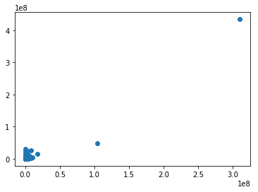

```python
from matplotlib import pyplot as plt
%matplotlib inline
plt.scatter(raw_df['total_payments'], raw_df['total_stock_value'])

raw_df[raw_df['total_payments'] > 1e8]
```

有两个非常明显的异常点，一个是TOTAL，很明显这是数据表格处理时加上去的统计值，并不代表具体的人物，理应移除。另一个是 LAY KENNETH L，也就是安然的CEO和chairman，也是涉案人员之一。

### 异常值2

验证此数据集正确性的一个方法是检查payments之和是否等于total_payments

```python
def error_data(df):
    return df[abs(df[payments_features[:-1]].sum(axis=1) - df['total_payments']) > 1]

error_data(raw_df)
```

|  | poi | salary | bonus | long_term_incentive | deferred_income | deferral_payments | loan_advances | other | expenses | director_fees | ... | exercised_stock_options | restricted_stock | restricted_stock_deferred | total_stock_value | email_address | from_messages | from_poi_to_this_person | from_this_person_to_poi | shared_receipt_with_poi | to_messages |
| --- | --- | --- | --- | --- | --- | --- | --- | --- | --- | --- | --- | --- | --- | --- | --- | --- | --- | --- | --- | --- | --- |
| BELFER ROBERT | False | NaN | NaN | NaN | NaN | -102500.0 | NaN | NaN | NaN | 3285.0 | ... | 3285.0 | NaN | 44093.0 | -44093.0 | NaN | NaN | NaN | NaN | NaN | NaN |
| BHATNAGAR SANJAY | False | NaN | NaN | NaN | NaN | NaN | NaN | 137864.0 | NaN | 137864.0 | ... | 2604490.0 | -2604490.0 | 15456290.0 | NaN | sanjay.bhatnagar@enron.com | 29.0 | 0.0 | 1.0 | 463.0 | 523.0 |

2 rows × 21 columns

可以看出有两个人的数据是有问题的。通过仔细观察可以发现似乎是错列了，BELFER ROBERT 的total_payments是 3285， 填写到 exercised_stock_options 里了； BHATNAGAR SANJAY 的total_payments是137864.0，填写到 director_fees 里了。

### 异常值3

LOCKHART EUGENE E 的所有特征全部为NaN，没有有用信息。

```python
raw_df.loc['LOCKHART EUGENE E']
```

```
poi                          False
salary                         NaN
bonus                          NaN
long_term_incentive            NaN
deferred_income                NaN
deferral_payments              NaN
loan_advances                  NaN
other                          NaN
expenses                       NaN
director_fees                  NaN
total_payments                 NaN
exercised_stock_options        NaN
restricted_stock               NaN
restricted_stock_deferred      NaN
total_stock_value              NaN
email_address                  NaN
from_messages                  NaN
from_poi_to_this_person        NaN
from_this_person_to_poi        NaN
shared_receipt_with_poi        NaN
to_messages                    NaN
Name: LOCKHART EUGENE E, dtype: object
```

### 处理异常值

```python
# 删除异常值
df = raw_df.drop(['TOTAL', 'LOCKHART EUGENE E'], errors='ignore')

# 修正 BELFER ROBERT 和 BHATNAGAR SANJAY 的数据
df.loc['BELFER ROBERT'] = df.loc['BELFER ROBERT'][payments_features + stock_features].shift(-1) \
    .append(df.loc['BELFER ROBERT'][email_features + ['poi']])

df.loc['BHATNAGAR SANJAY'] = df.loc['BHATNAGAR SANJAY'][payments_features + stock_features].shift(1)\
    .append(df.loc['BHATNAGAR SANJAY'][email_features + ['poi']])

# 去掉 email_adress列
df = df.drop(['email_address'], axis=1, errors='ignore')

# 将所有payment、stock数据的 NaN 值替换为 0
df[payments_features] = df[payments_features].replace(np.nan, 0)
df[stock_features] = df[stock_features].replace(np.nan, 0)

df.loc[['BELFER ROBERT', 'BHATNAGAR SANJAY']]
```

|  | poi | salary | bonus | long_term_incentive | deferred_income | deferral_payments | loan_advances | other | expenses | director_fees | total_payments | exercised_stock_options | restricted_stock | restricted_stock_deferred | total_stock_value | from_messages | from_poi_to_this_person | from_this_person_to_poi | shared_receipt_with_poi | to_messages |
| --- | --- | --- | --- | --- | --- | --- | --- | --- | --- | --- | --- | --- | --- | --- | --- | --- | --- | --- | --- | --- |
| BELFER ROBERT | False | 0.0 | 0.0 | 0.0 | -102500.0 | 0.0 | 0.0 | 0.0 | 3285.0 | 102500.0 | 3285.0 | 0.0 | 44093.0 | -44093.0 | 0.0 | NaN | NaN | NaN | NaN | NaN |
| BHATNAGAR SANJAY | False | 0.0 | 0.0 | 0.0 | 0.0 | 0.0 | 0.0 | 0.0 | 137864.0 | 0.0 | 137864.0 | 15456290.0 | 2604490.0 | -2604490.0 | 15456290.0 | 29.0 | 0.0 | 1.0 | 463.0 | 523.0 |

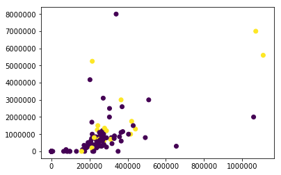

```python
plt.scatter(df['salary'], df['bonus'], c=df['poi'])
```

从图中无法看出明显的pattern。

## 算法选择

对数据进行简单处理后，尝试用几种算法训练模型，看看效果。

其次需要对数据集进行拆分，分为训练集和测试集。这样做是为了在训练集上训练，然后用测试集检查训练的效果。如果不这么做，用所有数据进行训练，得到的模型无法准确评估其泛化能力，即对未知数据的表现。

然后选择分类训练算法，这里使用sklearn提供的 GaussianNB、SVC和DecisionTreeClassifier分类器在训练集上进行训练。

最后使用测试集数据评估模型。评估标准使用 f1 score，综合了precision和recall两个指标。

```python
import sys

from sklearn.naive_bayes import GaussianNB
from sklearn.svm import SVC
from sklearn.tree import DecisionTreeClassifier
from sklearn.ensemble import AdaBoostClassifier
from sklearn.metrics import f1_score
from sklearn.model_selection import train_test_split

sys.path.append("../tools/")
from feature_format import featureFormat, targetFeatureSplit

### 准备数据集，选择特征

def prepare_data(dataframe, features_list=None):
    dataset = dataframe.to_dict(orient='index')
    if not features_list:
        features_list = dataframe.columns

    data = featureFormat(dataset, features_list, sort_keys=True)
    labels, features = targetFeatureSplit(data)
    return train_test_split(features, labels, test_size=0.3, random_state=42)
```

```python
# 使用4种分类器进行训练评估

def general_test(features_train, features_test, labels_train, labels_test):
    clf = GaussianNB()
    clf.fit(features_train, labels_train)
    t_score = f1_score(labels_train, clf.predict(features_train))
    score = f1_score(labels_test, clf.predict(features_test))
    print("F1 score of GaussianNB: %f / %f" % (t_score, score))

    clf = SVC()
    clf.fit(features_train, labels_train)
    t_score = f1_score(labels_train, clf.predict(features_train))
    score = f1_score(labels_test, clf.predict(features_test))
    print("F1 score of SVC: %f / %f" % (t_score, score))

    clf = DecisionTreeClassifier(random_state=1)
    clf.fit(features_train, labels_train)
    t_score = f1_score(labels_train, clf.predict(features_train))
    score = f1_score(labels_test, clf.predict(features_test))
    print("F1 score of DecisionTreeClassifier: %f / %f" % (t_score, score))

    clf = AdaBoostClassifier(random_state=1)
    clf.fit(features_train, labels_train)
    t_score = f1_score(labels_train, clf.predict(features_train))
    score = f1_score(labels_test, clf.predict(features_test))
    print("F1 score of AdaBoostClassifier: %f / %f" % (t_score, score))

# 使用tester评分

from tester import test_classifier

def test_clf(clf, df, fl=None):
    my_dataset = df.to_dict(orient='index')
    if not fl:
        fl = df.columns
    test_classifier(clf, my_dataset, fl)
```

```python
### 只使用income 数据
features_list = ['poi'] + payments_features + stock_features
features_train, features_test, labels_train, labels_test = prepare_data(df, features_list)

### 训练模型，评估模型
general_test(features_train, features_test, labels_train, labels_test)
```

```
F1 score of GaussianNB: 0.428571 / 0.600000
F1 score of SVC: 1.000000 / 0.000000
F1 score of DecisionTreeClassifier: 1.000000 / 0.200000
F1 score of AdaBoostClassifier: 1.000000 / 0.200000
```

由于数据量过少，训练模型使用训练数据很容易达到 1.0的最高评分。但是在测试数据上表现一般。这是由于数据量太少，算法训练效果太强，产生了过拟合。

```python
### 使用所有feature
features_train, features_test, labels_train, labels_test = prepare_data(df.replace(np.nan, 0))

### 训练模型，评估模型
general_test(features_train, features_test, labels_train, labels_test)
```

```
F1 score of GaussianNB: 0.428571 / 0.444444
F1 score of SVC: 1.000000 / 0.000000
F1 score of DecisionTreeClassifier: 1.000000 / 0.000000
F1 score of AdaBoostClassifier: 1.000000 / 0.222222
```

## 特征工程

从原始特征不足以训练出较好的模型。考虑数据的性质，尝试添加一些新的特征。

主要考虑各种特征的比例。

1. 某人发给poi的邮件数量 比上 此人发出邮件的总数量
2. 某人收到从poi发来的邮件数量 比上 此人接收邮件的总数量
3. 某人收到的邮件同时也是抄送给poi的 比上 此人收到的邮件总数量

如果这些比例较大，也很可能说明这个人也是poi

1. bonus / salary 奖金和工资的比例也可能说明问题
2. total_payments / total_stock_value 总收入和总股值的比例

```python
### 定义比例，分子分母加1 防止除以0。
def create_ratio_feature(df, a, b):
    return (df[a] + 1) / (df[b] + 1)
```

```python
df1 = df.copy()
df1['from_poi_ratio'] = create_ratio_feature(df1, 'from_this_person_to_poi', 'from_messages')
df1['to_poi_ratio'] = create_ratio_feature(df1, 'from_poi_to_this_person', 'to_messages')
df1['shared_poi_ratio'] = create_ratio_feature(df1, 'shared_receipt_with_poi', 'to_messages')
df1['bonus_to_salary'] = create_ratio_feature(df1, 'bonus', 'salary')
df1['payments_to_stock'] = create_ratio_feature(df1, 'total_payments', 'total_stock_value')
# df1['bonus_to_payments'] = create_ratio_feature(df1, 'bonus', 'total_payments')

df1 = df1.replace(np.nan, 0)
features_train, features_test, labels_train, labels_test = prepare_data(df1)

### 训练模型，评估模型
general_test(features_train, features_test, labels_train, labels_test)
```

```
F1 score of GaussianNB: 0.382353 / 0.258065
F1 score of SVC: 1.000000 / 0.000000
F1 score of DecisionTreeClassifier: 1.000000 / 0.153846
F1 score of AdaBoostClassifier: 1.000000 / 0.444444
```

可以看出，通过添加新特征后，AdaBoostClassifier 基本达到了要求。

### 特征选择

DecisionTree算法可以评估特征的重要性

```python
clf = DecisionTreeClassifier(random_state=222)
clf.fit(features_train, labels_train)
t_score = f1_score(labels_train, clf.predict(features_train))
score = f1_score(labels_test, clf.predict(features_test))
print("F1 score of DecisionTreeClassifier: %f / %f" % (t_score, score))
test_clf(clf, df1)
```

```
F1 score of DecisionTreeClassifier: 1.000000 / 0.285714
496 11550 1450 1504
DecisionTreeClassifier(class_weight=None, criterion='gini', max_depth=None,
            max_features=None, max_leaf_nodes=None,
            min_impurity_split=1e-07, min_samples_leaf=1,
            min_samples_split=2, min_weight_fraction_leaf=0.0,
            presort=False, random_state=222, splitter='best')
	Accuracy: 0.80307	Precision: 0.25488	Recall: 0.24800	F1: 0.25139	F2: 0.24935
	Total predictions: 15000	True positives:  496	False positives: 1450	False negatives: 1504	True negatives: 11550
```

```python
features_list = list(df1.columns)
features_list.remove('poi')
feature_importances = zip(features_list, clf.feature_importances_)
feature_importances = sorted(feature_importances, key=lambda x:x[1], reverse=True)

pprint(feature_importances)
```

```
[('exercised_stock_options', 0.22600000000000023),
 ('payments_to_stock', 0.14828456020380801),
 ('bonus', 0.12810523836079463),
 ('shared_poi_ratio', 0.12610474109558947),
 ('to_poi_ratio', 0.12451869894486046),
 ('bonus_to_salary', 0.087052558429770832),
 ('salary', 0.053512168141592924),
 ('restricted_stock', 0.041018273761636595),
 ('deferral_payments', 0.035674778761061954),
 ('shared_receipt_with_poi', 0.029728982300884967),
 ('long_term_incentive', 0.0),
 ('deferred_income', 0.0),
 ('loan_advances', 0.0),
 ('other', 0.0),
 ('expenses', 0.0),
 ('director_fees', 0.0),
 ('total_payments', 0.0),
 ('restricted_stock_deferred', 0.0),
 ('total_stock_value', 0.0),
 ('from_messages', 0.0),
 ('from_poi_to_this_person', 0.0),
 ('from_this_person_to_poi', 0.0),
 ('to_messages', 0.0),
 ('from_poi_ratio', 0.0)]
```

```python
features_list = ['poi'] + [f[0] for f in feature_importances if f[1] > 0]
features_train, features_test, labels_train, labels_test = prepare_data(df1, features_list)

clf = DecisionTreeClassifier(random_state=222)
clf.fit(features_train, labels_train)
t_score = f1_score(labels_train, clf.predict(features_train))
score = f1_score(labels_test, clf.predict(features_test))
print("F1 score of DecisionTreeClassifier: %f / %f" % (t_score, score))

test_clf(clf, df1, features_list)
```

```
F1 score of DecisionTreeClassifier: 1.000000 / 0.307692
606 11600 1400 1394
DecisionTreeClassifier(class_weight=None, criterion='gini', max_depth=None,
            max_features=None, max_leaf_nodes=None,
            min_impurity_split=1e-07, min_samples_leaf=1,
            min_samples_split=2, min_weight_fraction_leaf=0.0,
            presort=False, random_state=222, splitter='best')
	Accuracy: 0.81373	Precision: 0.30209	Recall: 0.30300	F1: 0.30255	F2: 0.30282
	Total predictions: 15000	True positives:  606	False positives: 1400	False negatives: 1394	True negatives: 11600
```

## 优化算法

### SVC 与特征缩放

支持向量机（Support Vector Machine，常简称为SVM）是一种监督式学习的方法，可广泛地应用于统计分类以及回归分析。支持向量机属于一般化线性分类器，这族分类器的特点是他们能够同时最小化经验误差与最大化几何边缘区，因此支持向量机也被称为最大边缘区分类器。

SVM分类器依赖特征点的几何距离，所以使用特征缩放可能会提升效果。

```python
from sklearn.preprocessing import scale

scaled_df = df1.copy()
scaled_df.loc[:] = scale(scaled_df)
scaled_df['poi'] = df['poi']

scaled_features_train, scaled_features_test, scaled_labels_train, scaled_labels_test = \
    prepare_data(scaled_df, features_list=None)
scaled_df.head()
```

|  | poi | salary | bonus | long_term_incentive | deferred_income | deferral_payments | loan_advances | other | expenses | director_fees | ... | from_messages | from_poi_to_this_person | from_this_person_to_poi | shared_receipt_with_poi | to_messages | from_poi_ratio | to_poi_ratio | shared_poi_ratio | bonus_to_salary | payments_to_stock |
| --- | --- | --- | --- | --- | --- | --- | --- | --- | --- | --- | --- | --- | --- | --- | --- | --- | --- | --- | --- | --- | --- |
| ALLEN PHILLIP K | False | 0.084076 | 2.847343 | -0.046953 | -4.781337 | 3.523494 | -0.086077 | -0.262702 | -0.490668 | -0.320349 | ... | 1.266865 | 0.111365 | 0.507857 | 0.656134 | 0.746012 | -0.491632 | -0.197044 | 0.325064 | 5.145137 | -0.207010 |
| BADUM JAMES P | False | -0.944434 | -0.550099 | -0.492058 | 0.321987 | -0.058334 | -0.086077 | -0.262836 | -0.717199 | -0.320349 | ... | -0.251505 | -0.523612 | -0.309745 | -0.654478 | -0.555460 | -0.651105 | -0.647212 | -0.981335 | -0.424097 | -0.207023 |
| BANNANTINE JAMES M | False | -0.942005 | -0.550099 | -0.492058 | 0.313533 | -0.296586 | -0.086077 | 0.504042 | 0.435201 | -0.320349 | ... | -0.231445 | 0.003284 | -0.309745 | -0.221333 | -0.301624 | -0.474235 | 1.273481 | 1.232386 | -0.706598 | -0.207026 |
| BAXTER JOHN C | False | 0.415855 | 0.426412 | 1.824052 | -1.973813 | 1.428261 | -0.086077 | 2.096995 | -0.548883 | -0.320349 | ... | -0.251505 | -0.523612 | -0.309745 | -0.654478 | -0.555460 | -0.651105 | -0.647212 | -0.981335 | 0.564647 | -0.207024 |
| BAY FRANKLIN R | False | 0.276155 | -0.224595 | -0.492058 | -0.012002 | 0.050123 | -0.086077 | -0.262775 | 2.024559 | -0.320349 | ... | -0.251505 | -0.523612 | -0.309745 | -0.654478 | -0.555460 | -0.651105 | -0.647212 | -0.981335 | -0.234722 | -0.206938 |

5 rows × 25 columns

```python
### 训练数据集
clf = SVC(kernel='linear')
clf.fit(scaled_features_train, scaled_labels_train)

# print(scaled_labels_train)
# print(clf.predict(scaled_features_train))

print('Accuracy(Training Data):', clf.score(scaled_features_train, scaled_labels_train))
print('F1 score(Training Data):', f1_score(scaled_labels_train, clf.predict(scaled_features_train)))

print('Accuracy(Test Data):', clf.score(scaled_features_test, scaled_labels_test))
print("F1 score(Test Data):", f1_score(scaled_labels_test, clf.predict(scaled_features_test)))

test_clf(clf, scaled_df)
```

```
('Accuracy(Training Data):', 0.92000000000000004)
('F1 score(Training Data):', 0.55555555555555558)
('Accuracy(Test Data):', 0.88636363636363635)
('F1 score(Test Data):', 0.44444444444444448)
308 12624 376 1692
SVC(C=1.0, cache_size=200, class_weight=None, coef0=0.0,
  decision_function_shape=None, degree=3, gamma='auto', kernel='linear',
  max_iter=-1, probability=False, random_state=None, shrinking=True,
  tol=0.001, verbose=False)
	Accuracy: 0.86213	Precision: 0.45029	Recall: 0.15400	F1: 0.22951	F2: 0.17734
	Total predictions: 15000	True positives:  308	False positives:  376	False negatives: 1692	True negatives: 12624
```

### 决策树和GridSearchCV

```python
from sklearn.model_selection import GridSearchCV, StratifiedKFold

features_train, features_test, labels_train, labels_test = prepare_data(df1)
features_list = df1.columns

clf = DecisionTreeClassifier(random_state=222)
parameters = {
    'criterion': ['entropy'],
    'max_depth': [None, 5, 10, 15, 20, 40],
    'max_features': range(1, len(features_list) - 1),
    'min_samples_split': [2, 4, 6, 8, 10],
}

cv = StratifiedKFold(10)

grid = GridSearchCV(clf, parameters, scoring='f1', cv=cv)
grid.fit(features_train, labels_train)

clf = grid.best_estimator_
print(clf)
print("Best Score: %f" % grid.best_score_)

print("Train Score: %f" % f1_score(labels_train, clf.predict(features_train)))
print("Test Score: %f" % f1_score(labels_test, clf.predict(features_test)))

feature_importances = zip(features_list[1:], clf.feature_importances_)

feature_importances.sort(key=lambda x:x[1], reverse=True)

pprint(feature_importances)
```

```
DecisionTreeClassifier(class_weight=None, criterion='entropy', max_depth=None,
            max_features=12, max_leaf_nodes=None, min_impurity_split=1e-07,
            min_samples_leaf=1, min_samples_split=4,
            min_weight_fraction_leaf=0.0, presort=False, random_state=222,
            splitter='best')
Best Score: 0.568000
Train Score: 0.960000
Test Score: 0.333333
[('bonus_to_salary', 0.39862350476074521),
 ('long_term_incentive', 0.13394778700450211),
 ('shared_poi_ratio', 0.12697352991809804),
 ('exercised_stock_options', 0.1220496726565619),
 ('restricted_stock', 0.088253852814764541),
 ('deferred_income', 0.068910324957479174),
 ('from_messages', 0.061241327887849174),
 ('salary', 0.0),
 ('bonus', 0.0),
 ('deferral_payments', 0.0),
 ('loan_advances', 0.0),
 ('other', 0.0),
 ('expenses', 0.0),
 ('director_fees', 0.0),
 ('total_payments', 0.0),
 ('restricted_stock_deferred', 0.0),
 ('total_stock_value', 0.0),
 ('from_poi_to_this_person', 0.0),
 ('from_this_person_to_poi', 0.0),
 ('shared_receipt_with_poi', 0.0),
 ('to_messages', 0.0),
 ('from_poi_ratio', 0.0),
 ('to_poi_ratio', 0.0),
 ('payments_to_stock', 0.0)]
```

```python
test_clf(clf, df1)
```

```
656 11575 1425 1344
DecisionTreeClassifier(class_weight=None, criterion='entropy', max_depth=None,
            max_features=12, max_leaf_nodes=None, min_impurity_split=1e-07,
            min_samples_leaf=1, min_samples_split=4,
            min_weight_fraction_leaf=0.0, presort=False, random_state=222,
            splitter='best')
	Accuracy: 0.81540	Precision: 0.31523	Recall: 0.32800	F1: 0.32149	F2: 0.32536
	Total predictions: 15000	True positives:  656	False positives: 1425	False negatives: 1344	True negatives: 11575
```

### AdaBoost

```python
clf = AdaBoostClassifier()
parameters = {
    'n_estimators': range(50, 100, 10),
}

grid = GridSearchCV(clf, parameters, scoring='f1', cv=10)
grid.fit(features_train, labels_train)

clf = grid.best_estimator_
print('Accuracy(Training Data):', clf.score(features_train, labels_train))
print('F1 score(Training Data):', f1_score(labels_train, clf.predict(features_train)))

print('Accuracy(Test Data):', clf.score(features_test, labels_test))
print("F1 score(Test Data):", f1_score(labels_test, clf.predict(features_test)))

test_clf(clf, df1)
```

```
('Accuracy(Training Data):', 1.0)
('F1 score(Training Data):', 1.0)
('Accuracy(Test Data):', 0.84090909090909094)
('F1 score(Test Data):', 0.36363636363636359)
666 12166 834 1334
AdaBoostClassifier(algorithm='SAMME.R', base_estimator=None,
          learning_rate=1.0, n_estimators=60, random_state=None)
	Accuracy: 0.85547	Precision: 0.44400	Recall: 0.33300	F1: 0.38057	F2: 0.35053
	Total predictions: 15000	True positives:  666	False positives:  834	False negatives: 1334	True negatives: 12166
```